# Credit Risk Prediction

## 5. Preparing Data for Modelling:

We prep the data for modelling in this step.

### 5.1 Converting Datatypes:

The variables: age, employment, savings_status, duration, checking_status, having 'category data type' are converted to 'object data type' using '.astype(np.object)'

```python
crdt_cat.dtypes
crdt_cat['checking_status'] = crdt_cat['checking_status'].astype(np.object)
crdt_cat['duration'] = crdt_cat['duration'].astype(np.object)
crdt_cat['savings_status'] = crdt_cat['savings_status'].astype(np.object)
crdt_cat['employment'] = crdt_cat['employment'].astype(np.object)
crdt_cat['age'] = crdt_cat['age'].astype(np.object)
crdt_cat.dtypes
```

```
checking_status           object
duration                  object
credit_history            object
purpose                   object
credit_amount              int64
savings_status            object
employment                object
installment_commitment     int64
personal_status           object
other_parties             object
residence_since            int64
property_magnitude        object
age                       object
other_payment_plans       object
housing                   object
existing_credits           int64
job                       object
num_dependents             int64
own_telephone             object
foreign_worker            object
class                     object
dtype: object
```

### 5.2 Separating Target Feature:

In the 'crdt_cat' dataset, the variable 'class' is dropped and the name 'data' is assigned to the rest. The 'class' feature in the dataset is assigned name, 'target.'

```python
data = crdt_cat.drop(columns = 'class')

target = crdt_cat['class']
```

### 5.3 Label Encoding:

On the target feature, label encoding is performed to make it easier for modelling. The positive class 'good' is assigned as 0, whereas 'bad' is assigned as 1

```python
target = target.replace({'good': 0, 'bad': 1})

target.value_counts()
```

```
0    700
1    300
Name: class, dtype: int64
```

In the next step, the list of all the features with category data type, is displayed and is assigned to 'cat_cols'

```python
cat_cols = data.columns[data.dtypes == 'object'].tolist()
cat_cols
```

```
['checking_status',
 'duration',
 'credit_history',
 'purpose',
 'savings_status',
 'employment',
 'personal_status',
 'other_parties',
 'property_magnitude',
 'age',
 'other_payment_plans',
 'housing',
 'job',
 'own_telephone',
 'foreign_worker']
```

For all the features in the 'cat_cols', their categories along with value counts is displayed.

```python
for cat_col in cat_cols:
    print(cat_col + ':')
    print(data[cat_col].value_counts())
    print('\n')
```

```
checking_status:
no_account          394
less_than_0         274
0_to_200            269
greater_than_200     63
Name: checking_status, dtype: int64


duration:
medium_term    411
short_term     359
long_term      230
Name: duration, dtype: int64


credit_history:
existing paid                     530
critical/other existing credit    293
delayed previously                 88
all paid                           49
no credits/all paid                40
Name: credit_history, dtype: int64


purpose:
radio/tv               280
new car                234
furniture/equipment    181
used car               103
business                97
education               50
repairs                 22
domestic appliance      12
other                   12
retraining               9
Name: purpose, dtype: int64


savings_status:
less_than_100_marks        603
```

[output cut: 63 more lines]

```
high qualif/self emp/mgmt    148
unemp/unskilled non res       22
Name: job, dtype: int64


own_telephone:
none    596
yes     404
Name: own_telephone, dtype: int64


foreign_worker:
yes    963
no      37
Name: foreign_worker, dtype: int64
```

### 5.4 One-hot encoding

In the next step:

- All the two-level categorical features, are encoded to a single column of 0 or 1.
- For the variables with more than two-levels, 'get_dummies()' is applied to perform one hot encoding.

```python
crdt_encoded = data.copy()
for col in cat_cols:
    q = len(crdt_encoded[col].unique())
    if (q == 2):
        crdt_encoded[col] = pd.get_dummies(crdt_encoded[col], drop_first=True)
```

```python
crdt_encoded = pd.get_dummies(crdt_encoded)
```

```python
print(f'Shape of crdt_encoded is {crdt_encoded.shape}\n')

crdt_encoded.sample(n=4, random_state=11)
```

```
Shape of crdt_encoded is (1000, 63)
```

|  | credit_amount | installment_commitment | residence_since | existing_credits | num_dependents | own_telephone | foreign_worker | checking_status_0_to_200 | checking_status_greater_than_200 | checking_status_less_than_0 | checking_status_no_account | duration_long_term | duration_medium_term | duration_short_term | credit_history_all paid | credit_history_critical/other existing credit | credit_history_delayed previously | credit_history_existing paid | credit_history_no credits/all paid | purpose_business | purpose_domestic appliance | purpose_education | purpose_furniture/equipment | purpose_new car | purpose_other | purpose_radio/tv | purpose_repairs | purpose_retraining | purpose_used car | … |
| --- | --- | --- | --- | --- | --- | --- | --- | --- | --- | --- | --- | --- | --- | --- | --- | --- | --- | --- | --- | --- | --- | --- | --- | --- | --- | --- | --- | --- | --- | --- |
| 25 | 1374 | 1 | 2 | 1 | 1 | 1 | 1 | 0 | 0 | 1 | 0 | 0 | 0 | 1 | 0 | 0 | 0 | 1 | 0 | 0 | 0 | 0 | 1 | 0 | 0 | 0 | 0 | 0 | 0 | … |
| 464 | 1950 | 4 | 1 | 2 | 1 | 1 | 1 | 0 | 0 | 0 | 1 | 0 | 1 | 0 | 0 | 0 | 0 | 1 | 0 | 1 | 0 | 0 | 0 | 0 | 0 | 0 | 0 | 0 | 0 | … |
| 372 | 2146 | 1 | 3 | 2 | 1 | 0 | 1 | 0 | 0 | 0 | 1 | 0 | 0 | 1 | 0 | 1 | 0 | 0 | 0 | 0 | 0 | 0 | 1 | 0 | 0 | 0 | 0 | 0 | 0 | … |
| 730 | 6403 | 1 | 2 | 1 | 1 | 0 | 1 | 1 | 0 | 0 | 0 | 0 | 1 | 0 | 0 | 0 | 1 | 0 | 0 | 0 | 0 | 0 | 0 | 0 | 0 | 1 | 0 | 0 | 0 | … |

```python
crdt_encoded.describe(include='all').round(3)
```

|  | credit_amount | installment_commitment | residence_since | existing_credits | num_dependents | own_telephone | foreign_worker | checking_status_0_to_200 | checking_status_greater_than_200 | checking_status_less_than_0 | checking_status_no_account | duration_long_term | duration_medium_term | duration_short_term | credit_history_all paid | credit_history_critical/other existing credit | credit_history_delayed previously | credit_history_existing paid | credit_history_no credits/all paid | purpose_business | purpose_domestic appliance | purpose_education | purpose_furniture/equipment | purpose_new car | purpose_other | purpose_radio/tv | purpose_repairs | purpose_retraining | purpose_used car | … |
| --- | --- | --- | --- | --- | --- | --- | --- | --- | --- | --- | --- | --- | --- | --- | --- | --- | --- | --- | --- | --- | --- | --- | --- | --- | --- | --- | --- | --- | --- | --- |
| count | 1000.000 | 1000.000 | 1000.000 | 1000.000 | 1000.000 | 1000.000 | 1000.000 | 1000.000 | 1000.000 | 1000.000 | 1000.000 | 1000.000 | 1000.000 | 1000.000 | 1000.000 | 1000.000 | 1000.000 | 1000.000 | 1000.000 | 1000.000 | 1000.000 | 1000.000 | 1000.000 | 1000.000 | 1000.000 | 1000.000 | 1000.000 | 1000.000 | 1000.000 | … |
| mean | 3271.258 | 2.973 | 2.845 | 1.407 | 1.155 | 0.404 | 0.963 | 0.269 | 0.063 | 0.274 | 0.394 | 0.230 | 0.411 | 0.359 | 0.049 | 0.293 | 0.088 | 0.530 | 0.040 | 0.097 | 0.012 | 0.050 | 0.181 | 0.234 | 0.012 | 0.280 | 0.022 | 0.009 | 0.103 | … |
| std | 2822.737 | 1.119 | 1.104 | 0.578 | 0.362 | 0.491 | 0.189 | 0.444 | 0.243 | 0.446 | 0.489 | 0.421 | 0.492 | 0.480 | 0.216 | 0.455 | 0.283 | 0.499 | 0.196 | 0.296 | 0.109 | 0.218 | 0.385 | 0.424 | 0.109 | 0.449 | 0.147 | 0.094 | 0.304 | … |
| min | 250.000 | 1.000 | 1.000 | 1.000 | 1.000 | 0.000 | 0.000 | 0.000 | 0.000 | 0.000 | 0.000 | 0.000 | 0.000 | 0.000 | 0.000 | 0.000 | 0.000 | 0.000 | 0.000 | 0.000 | 0.000 | 0.000 | 0.000 | 0.000 | 0.000 | 0.000 | 0.000 | 0.000 | 0.000 | … |
| 25% | 1365.500 | 2.000 | 2.000 | 1.000 | 1.000 | 0.000 | 1.000 | 0.000 | 0.000 | 0.000 | 0.000 | 0.000 | 0.000 | 0.000 | 0.000 | 0.000 | 0.000 | 0.000 | 0.000 | 0.000 | 0.000 | 0.000 | 0.000 | 0.000 | 0.000 | 0.000 | 0.000 | 0.000 | 0.000 | … |
| 50% | 2319.500 | 3.000 | 3.000 | 1.000 | 1.000 | 0.000 | 1.000 | 0.000 | 0.000 | 0.000 | 0.000 | 0.000 | 0.000 | 0.000 | 0.000 | 0.000 | 0.000 | 1.000 | 0.000 | 0.000 | 0.000 | 0.000 | 0.000 | 0.000 | 0.000 | 0.000 | 0.000 | 0.000 | 0.000 | … |
| 75% | 3972.250 | 4.000 | 4.000 | 2.000 | 1.000 | 1.000 | 1.000 | 1.000 | 0.000 | 1.000 | 1.000 | 0.000 | 1.000 | 1.000 | 0.000 | 1.000 | 0.000 | 1.000 | 0.000 | 0.000 | 0.000 | 0.000 | 0.000 | 0.000 | 0.000 | 1.000 | 0.000 | 0.000 | 0.000 | … |
| max | 18424.000 | 4.000 | 4.000 | 4.000 | 2.000 | 1.000 | 1.000 | 1.000 | 1.000 | 1.000 | 1.000 | 1.000 | 1.000 | 1.000 | 1.000 | 1.000 | 1.000 | 1.000 | 1.000 | 1.000 | 1.000 | 1.000 | 1.000 | 1.000 | 1.000 | 1.000 | 1.000 | 1.000 | 1.000 | … |

### 5.5 Scaling:

After performing the encoding, the data is scaled using preprocessing function '.MinMaxScaler()'

```python
from sklearn import preprocessing

crdt_scaler = preprocessing.MinMaxScaler()

crdt_sc = crdt_scaler.fit_transform(crdt_encoded)
```

```python
crdt_df1 = pd.DataFrame(crdt_sc,columns=crdt_encoded.columns)

crdt_df1.sample(n=4, random_state=11).round(3)
```

|  | credit_amount | installment_commitment | residence_since | existing_credits | num_dependents | own_telephone | foreign_worker | checking_status_0_to_200 | checking_status_greater_than_200 | checking_status_less_than_0 | checking_status_no_account | duration_long_term | duration_medium_term | duration_short_term | credit_history_all paid | credit_history_critical/other existing credit | credit_history_delayed previously | credit_history_existing paid | credit_history_no credits/all paid | purpose_business | purpose_domestic appliance | purpose_education | purpose_furniture/equipment | purpose_new car | purpose_other | purpose_radio/tv | purpose_repairs | purpose_retraining | purpose_used car | … |
| --- | --- | --- | --- | --- | --- | --- | --- | --- | --- | --- | --- | --- | --- | --- | --- | --- | --- | --- | --- | --- | --- | --- | --- | --- | --- | --- | --- | --- | --- | --- |
| 25 | 0.062 | 0.0 | 0.333 | 0.000 | 0.0 | 1.0 | 1.0 | 0.0 | 0.0 | 1.0 | 0.0 | 0.0 | 0.0 | 1.0 | 0.0 | 0.0 | 0.0 | 1.0 | 0.0 | 0.0 | 0.0 | 0.0 | 1.0 | 0.0 | 0.0 | 0.0 | 0.0 | 0.0 | 0.0 | … |
| 464 | 0.094 | 1.0 | 0.000 | 0.333 | 0.0 | 1.0 | 1.0 | 0.0 | 0.0 | 0.0 | 1.0 | 0.0 | 1.0 | 0.0 | 0.0 | 0.0 | 0.0 | 1.0 | 0.0 | 1.0 | 0.0 | 0.0 | 0.0 | 0.0 | 0.0 | 0.0 | 0.0 | 0.0 | 0.0 | … |
| 372 | 0.104 | 0.0 | 0.667 | 0.333 | 0.0 | 0.0 | 1.0 | 0.0 | 0.0 | 0.0 | 1.0 | 0.0 | 0.0 | 1.0 | 0.0 | 1.0 | 0.0 | 0.0 | 0.0 | 0.0 | 0.0 | 0.0 | 1.0 | 0.0 | 0.0 | 0.0 | 0.0 | 0.0 | 0.0 | … |
| 730 | 0.339 | 0.0 | 0.333 | 0.000 | 0.0 | 0.0 | 1.0 | 1.0 | 0.0 | 0.0 | 0.0 | 0.0 | 1.0 | 0.0 | 0.0 | 0.0 | 1.0 | 0.0 | 0.0 | 0.0 | 0.0 | 0.0 | 0.0 | 0.0 | 0.0 | 1.0 | 0.0 | 0.0 | 0.0 | … |

## 6. Feature Selection & Ranking

### 6.1 RFI

- To perform the algorithm, 'RandomForestClassifier' is imported in the python workspace.
- Then, Random Forest model is performed on the encoded data and the target feature, using 'RandomForestClassifier(n_estimators=100).fit()'
- Further, the important features are selected and are sorted accordingly.
- Finally the best 5 features are assigned to 'best_features_rfi'

```python
## Feature Selection
from sklearn.ensemble import RandomForestClassifier

imp_features = 5
rfi1 = RandomForestClassifier(n_estimators=100)
rfi1.fit(crdt_sc, target)
rfi2 = np.argsort(rfi1.feature_importances_)[::-1][0:imp_features]

rfi3 = crdt_df1.columns[rfi2].values
rfi3
```

```
array(['credit_amount', 'checking_status_no_account',
       'checking_status_less_than_0', 'installment_commitment',
       'residence_since'], dtype=object)
```

### 6.2 Calculating importance scores of features:

Hence, after performing feature selection, certain features are available that provide the best result.

```python
rfi4 = rfi1.feature_importances_[rfi2]
rfi4
```

```
array([0.10684764, 0.05245072, 0.03982985, 0.0390945 , 0.03660883])
```

```python
%config InlineBackend.figure_format = 'retina'
def plot(best_features, scores, method_name, color):

    df = pd.DataFrame({'features': best_features,
                       'importances': scores})

    chart = alt.Chart(df,
                      width=500,
                      title=method_name + ' Feature Importances'
                     ).mark_bar(opacity=0.85,
                                color=color).encode(
        alt.X('features', title='Feature', sort=None, axis=alt.AxisConfig(labelAngle=45)),
        alt.Y('importances', title='Importance')
    )

    return chart
```

[output not shown]

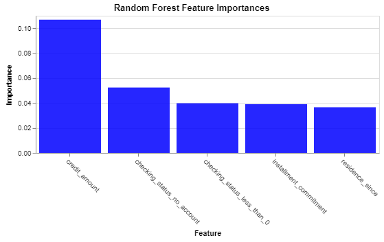

```python
plot(rfi3, rfi4, 'Random Forest', 'blue')
```

We can infer that 'credit amount' is the most important feature. Next best features are checking status and installment commitment.

## 7. Data Splitting

In order to perform modelling on data and target:

- First, 'train_test_split' is imported from sklearn.
- Then the data and target are split randomly in the ratio of 70:30, 30 being the test portion.
- Finally, the dimensions of the train and test portion is analysed using, '.shape' function.

```python
## Splitting
from sklearn.model_selection import train_test_split

Dtrain, Dtest, ttrain, ttest = train_test_split(crdt_sc, target,
                                        test_size = 0.3, random_state=999,
                                          stratify = target)

print(Dtrain.shape)
print(Dtest.shape)
```

```
(700, 63)
(300, 63)
```

## 8. Hyperparameter Tuning

### 8.1 6-fold cross-validation:

6-fold stratified cross-validation is performed for hyperparameter tuning of each model.

```python
from sklearn.model_selection import StratifiedKFold, GridSearchCV

k_fold = StratifiedKFold(n_splits=6, random_state=999)
```

### 8.2 Defining feature selector function:

RFIFeatureSelector() function is defined foe feature selection. It will later be used to pick best features during modelling.

```python
from sklearn.base import BaseEstimator, TransformerMixin

class RFIFeatureSelector(BaseEstimator, TransformerMixin):

    def __init__(self, n_features_=20):
        self.n_features_ = n_features_
        self.fs_indices_ = None

    def fit(self, X, y):
        from sklearn.ensemble import RandomForestClassifier
        from numpy import argsort
        rfi1 = RandomForestClassifier(n_estimators=100)
        rfi1.fit(X, y)
        self.fs_indices_ = argsort(rfi1.feature_importances_)[::-1][0:self.n_features_]
        return self

    def transform(self, X, y=None):
        return X[:, self.fs_indices_]
```

## 9. K-Nearest Neighbours (K-NN)

### 9.1 Pipeline and Grid search:

Features selected by RFI, different values of nearest neighbours and other parameters obtained by fine tuning are passed in a single pipeline. Model evaluation is done using grid search where area under curve metric is used for evaluating the best parameters. 'n_neighbours' refers to number of neighbours and 'p' is the distance metric.

```python
from sklearn.pipeline import Pipeline
from sklearn.neighbors import KNeighborsClassifier

pipe1 = Pipeline(steps=[('rfi_fs', RFIFeatureSelector()),
                           ('knn', KNeighborsClassifier())])

params_pipe1 = {'rfi_fs__n_features_': [10, 20, 30, 40, 50, crdt_sc.shape[1]],
                   'knn__n_neighbors': [1, 5, 10, 15, 20],
                   'knn__p': [1, 2]}

g_pipe1 = GridSearchCV(estimator=pipe1,
                           param_grid=params_pipe1,
                           cv=k_fold,
                           refit=True,
                           n_jobs=-3,
                           scoring='roc_auc',
                           verbose=1)
```

```python
g_pipe1.fit(Dtrain, ttrain);
```

```
Fitting 6 folds for each of 60 candidates, totalling 360 fits
```

```
[Parallel(n_jobs=-3)]: Using backend SequentialBackend with 1 concurrent workers.
[Parallel(n_jobs=-3)]: Done 360 out of 360 | elapsed:  1.4min finished
```

```python
g_pipe1.best_params_
```

```
{'knn__n_neighbors': 20, 'knn__p': 1, 'rfi_fs__n_features_': 50}
```

```python
g_pipe1.best_score_
```

```
0.7894804429450191
```

We can observe that the best K-NN model has 20 neighbours and takes 50 features into account. The preferred distance metric is 1 which is Manhattan Distance. The mean AUC score obtained is 0.789.

### 9.2 Visualizing scores of models with different parameters:

We plot the AUC scores of models with different combinations of parameters in order to check for significant statistical differences between the scores. This can be done by creating a dataframe which consists the outputs from grid search.

```python
# custom function to format the search results as a Pandas data frame
def get_search_results(gs):

    def model_result(scores, params):
        scores = {'mean_score': np.mean(scores),
             'std_score': np.std(scores),
             'min_score': np.min(scores),
             'max_score': np.max(scores)}
        return pd.Series({**params,**scores})

    models = []
    scores = []

    for i in range(gs.n_splits_):
        key = f"split{i}_test_score"
        r = gs.cv_results_[key]
        scores.append(r.reshape(-1,1))

    all_scores = np.hstack(scores)
    for p, s in zip(gs.cv_results_['params'], all_scores):
        models.append((model_result(s, p)))

    pipe_results = pd.concat(models, axis=1).T.sort_values(['mean_score'], ascending=False)

    columns_first = ['mean_score', 'std_score', 'max_score', 'min_score']
    columns = columns_first + [c for c in pipe_results.columns if c not in columns_first]

    return pipe_results[columns]
```

```python
results_KNN = get_search_results(g_pipe1)
results_KNN.head()
```

|  | mean_score | std_score | max_score | min_score | knn__n_neighbors | knn__p | rfi_fs__n_features_ |
| --- | --- | --- | --- | --- | --- | --- | --- |
| 52 | 0.789561 | 0.030536 | 0.830159 | 0.732404 | 20.0 | 1.0 | 50.0 |
| 47 | 0.781140 | 0.033171 | 0.843386 | 0.751220 | 15.0 | 2.0 | 63.0 |
| 50 | 0.780913 | 0.027089 | 0.818467 | 0.731185 | 20.0 | 1.0 | 30.0 |
| 58 | 0.778698 | 0.027003 | 0.831041 | 0.741463 | 20.0 | 2.0 | 50.0 |
| 44 | 0.778696 | 0.028233 | 0.827513 | 0.735366 | 15.0 | 2.0 | 30.0 |

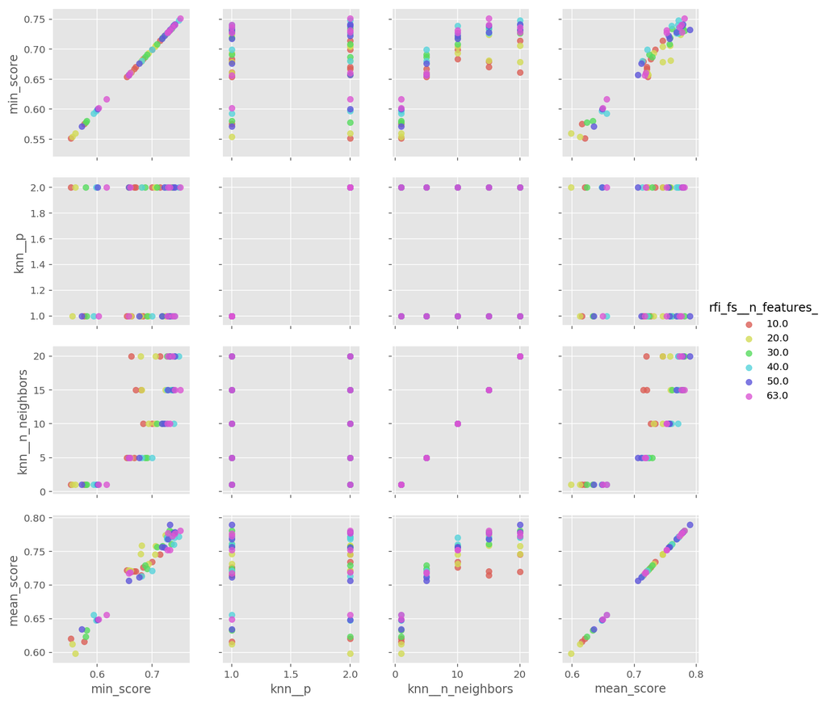

```python
import matplotlib.pyplot as plt
import seaborn as sns
import patsy
plt.style.use("ggplot")
%matplotlib inline
%config InlineBackend.figure_format = 'retina'
g = sns.PairGrid(results_KNN, vars=['min_score', 'knn__p', 'knn__n_neighbors', 'mean_score'],
                 hue='rfi_fs__n_features_', palette='hls')
g.map(plt.scatter, alpha=0.8)
g.add_legend();
```

As we can see, the difference between AUC scores for various combinations of parameters is not that significant. Although, a dominance of 63 features is seen on higher minimum AUC scores. Mean scores are not significantly different for various parameter combinations.

## 10. Decision Tree

### 10.1 Pipeline and Grid search:

Features are selected by RFIFeatureSelector() function, 'gini' index is used to calculate information gain, different values of maximum depth and minimum splits are all passed in a Pipeline and best parameters are deduced. The variables 'dt**max_depth' and 'dt**min_samples_split' represent maximum depth and minimum splits respectively. AUC scores are used to measure the performance of models after tuning.

```python
from sklearn.tree import DecisionTreeClassifier

pipe2 = Pipeline([('rfi_fs', RFIFeatureSelector()),
                    ('dt', DecisionTreeClassifier(criterion='gini', random_state=111))])

params_pipe2 = {'rfi_fs__n_features_': [10, 20, 30, 40, 50, crdt_sc.shape[1]],
                  'dt__max_depth': [3, 4, 5, 6],
                  'dt__min_samples_split': [2, 3, 5]}

g_pipe2 = GridSearchCV(estimator=pipe2,
                          param_grid=params_pipe2,
                          cv=k_fold,
                          refit=True,
                          n_jobs=-3,
                          scoring='roc_auc',
                          verbose=1)

g_pipe2.fit(Dtrain, ttrain);
```

```
Fitting 6 folds for each of 72 candidates, totalling 432 fits
```

```
[Parallel(n_jobs=-3)]: Using backend SequentialBackend with 1 concurrent workers.
[Parallel(n_jobs=-3)]: Done 432 out of 432 | elapsed:  1.7min finished
```

```python
g_pipe2.best_params_
```

```
{'dt__max_depth': 4, 'dt__min_samples_split': 5, 'rfi_fs__n_features_': 50}
```

```python
g_pipe2.best_score_
```

```
0.735313767060573
```

We obtain best results when maximum depth is 4, minimum splits are 5 and 50 features are taken into account. AUC mean score for this model is 0.735

### 10.2 Visualizing scores of models with different parameters:

We plot the AUC scores of models with different combinations of parameters in order to check for significant statistical differences between the scores. This can be done by creating a dataframe which consists the outputs from grid search.

```python
results_DT = get_search_results(g_pipe2)
results_DT.head()
```

|  | mean_score | std_score | max_score | min_score | dt__max_depth | dt__min_samples_split | rfi_fs__n_features_ |
| --- | --- | --- | --- | --- | --- | --- | --- |
| 34 | 0.735468 | 0.051307 | 0.816226 | 0.665505 | 4.0 | 5.0 | 50.0 |
| 28 | 0.730038 | 0.050499 | 0.816226 | 0.665505 | 4.0 | 3.0 | 50.0 |
| 33 | 0.726988 | 0.054421 | 0.812698 | 0.665505 | 4.0 | 5.0 | 40.0 |
| 29 | 0.725921 | 0.060724 | 0.816226 | 0.632753 | 4.0 | 3.0 | 63.0 |
| 23 | 0.725921 | 0.060724 | 0.816226 | 0.632753 | 4.0 | 2.0 | 63.0 |

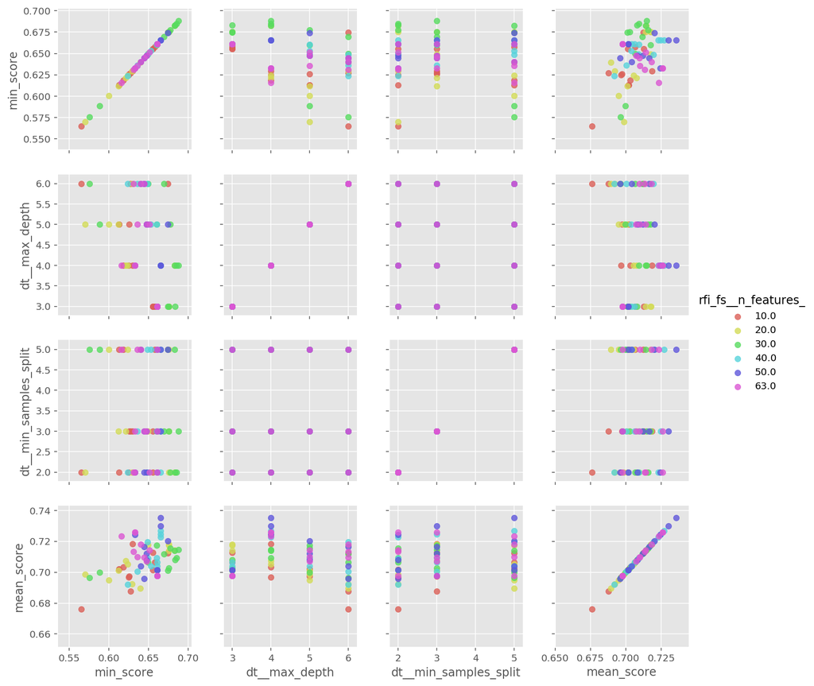

```python
g = sns.PairGrid(results_DT, vars=['min_score', 'dt__max_depth', 'dt__min_samples_split', 'mean_score'],
                 hue='rfi_fs__n_features_', palette='hls')
g.map(plt.scatter, alpha=0.8)
g.add_legend();
```

Hence, we can conclude that there are no significant statistical differences between various combinations of parameters.

## 11. Naive Bayes

### 11.1 Pipeline and Grid search:

In this Gaussian Naive Bayes model, var_smoothing, Laplace smoothing variant, is optimized. Best features are selected by RFIFeatureSelector() and is passed into a Pipeline. Grid search is conducted in logspace where initial value is 10 and final value is $10^{-2}$, where 100 different values are considered. Random search is performed over 10 values for runtime optimization. Power transformation is conducted on the input data followed by model fitting.

```python
from sklearn.preprocessing import PowerTransformer
Dtrain_trans = PowerTransformer().fit_transform(Dtrain)
```

```python
from sklearn.naive_bayes import GaussianNB
from sklearn.model_selection import RandomizedSearchCV

pipe4 = Pipeline([('rfi_fs', RFIFeatureSelector()),
                     ('nb', GaussianNB())])

params_pipe4 = {'rfi_fs__n_features_': [10, 20, 30, 40, 50, crdt_sc.shape[1]],
                  'nb__var_smoothing': np.logspace(1,-2, num=100)}

n_iter_search = 10
g_pipe4 = RandomizedSearchCV(estimator=pipe4,
                          param_distributions=params_pipe4,
                          cv=k_fold,
                          refit=True,
                          n_jobs=-3,
                          scoring='roc_auc',
                          n_iter=n_iter_search,
                          verbose=1)

g_pipe4.fit(Dtrain_trans, ttrain);
```

```
Fitting 6 folds for each of 10 candidates, totalling 60 fits
```

```
[Parallel(n_jobs=-3)]: Using backend SequentialBackend with 1 concurrent workers.
[Parallel(n_jobs=-3)]: Done  60 out of  60 | elapsed:   12.6s finished
```

```python
g_pipe4.best_params_
```

```
{'rfi_fs__n_features_': 50, 'nb__var_smoothing': 4.0370172585965545}
```

```python
g_pipe4.best_score_
```

```
0.7787871983481739
```

Evidently, the model works best when 50 features are selected and var_smoothing parameter value is 4.037. The mean AUC score for best model is 0.778.

### 11.2 Visualizing scores of models with different parameters:

We plot the AUC scores of models with different combinations of parameters in order to check for significant statistical differences between the scores. This can be done by creating a dataframe which consists the outputs from grid search.

```python
results_NB = get_search_results(g_pipe4)
results_NB.head()
```

|  | mean_score | std_score | max_score | min_score | rfi_fs__n_features_ | nb__var_smoothing |
| --- | --- | --- | --- | --- | --- | --- |
| 5 | 0.778814 | 0.020572 | 0.818695 | 0.758025 | 50.0 | 4.037017 |
| 0 | 0.776307 | 0.031970 | 0.837743 | 0.734039 | 50.0 | 3.764936 |
| 4 | 0.772021 | 0.031543 | 0.835273 | 0.741115 | 30.0 | 0.024771 |
| 2 | 0.770046 | 0.029474 | 0.818695 | 0.729806 | 30.0 | 0.705480 |
| 6 | 0.760082 | 0.028942 | 0.803880 | 0.719164 | 20.0 | 1.072267 |

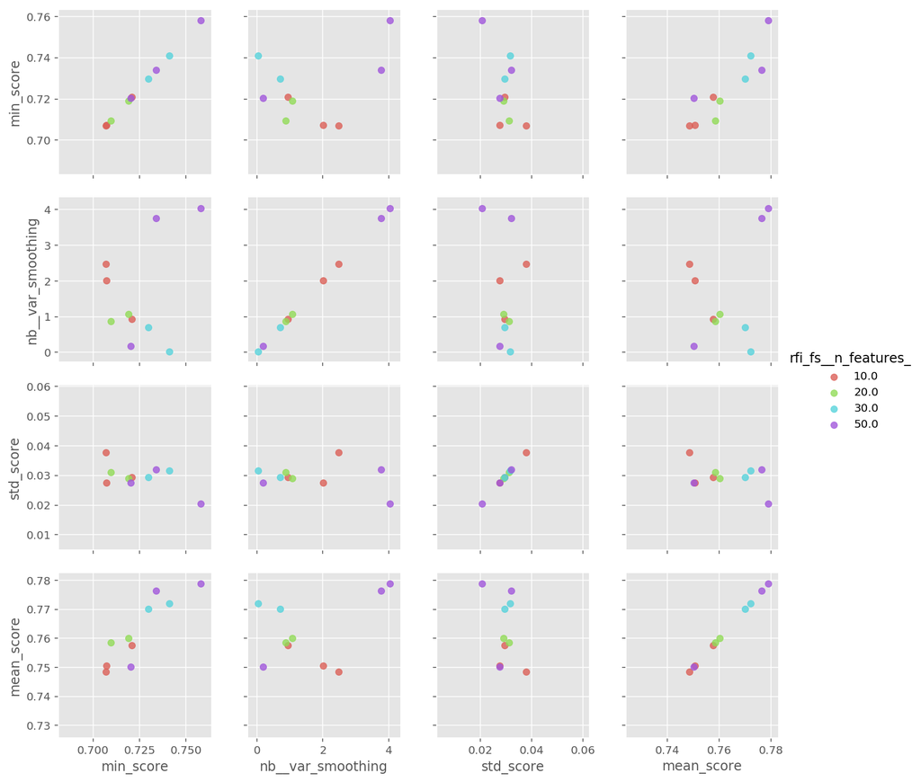

```python
g = sns.PairGrid(results_NB, vars=['min_score', 'nb__var_smoothing', 'std_score', 'mean_score'],
                 hue='rfi_fs__n_features_', palette='hls')
g.map(plt.scatter, alpha=0.8)
g.add_legend();
```

## 12. Random Forest

### 12.1 Pipeline and Grid search:

Best features selected by RFIFeatureSelector(), parametric values of maximum depth and minimum splits are passed into a single pipeline and grid search is performed for parameter tuning. Area Under Curve metric is used to score the models with different parameters.

```python
from sklearn.ensemble import RandomForestClassifier
from sklearn.metrics import accuracy_score
from sklearn.model_selection import RandomizedSearchCV
```

```python
pipe5 = Pipeline([('rfi_fs', RFIFeatureSelector()),
                    ('dt', RandomForestClassifier(random_state=111))])

params_pipe5 = {'rfi_fs__n_features_': [10, 20, 30, 40, 50, crdt_sc.shape[1]],
                  'dt__max_depth': [3, 4, 5, 6],
                  'dt__min_samples_split': [2, 3, 5]}

g_pipe5 = GridSearchCV(estimator=pipe5,
                          param_grid=params_pipe5,
                          cv=k_fold,
                          refit=True,
                          n_jobs=-3,
                          scoring='roc_auc',
                          verbose=1)

g_pipe5.fit(Dtrain, ttrain);
```

```
Fitting 6 folds for each of 72 candidates, totalling 432 fits
```

```
[Parallel(n_jobs=-3)]: Using backend SequentialBackend with 1 concurrent workers.
[Parallel(n_jobs=-3)]: Done 432 out of 432 | elapsed:  1.6min finished
```

```python
g_pipe5.best_params_
```

```
{'dt__max_depth': 4, 'dt__min_samples_split': 2, 'rfi_fs__n_features_': 30}
```

```python
g_pipe5.best_score_
```

```
0.7898448770655508
```

As we can observe, the model which takes 30 features, 4 as maximum depth and 2 as minimum splits gives the best AUC score which is 0.789.

### 12.2 Visualizing scores of models with different parameters:

We plot the AUC scores of models with different combinations of parameters in order to check for significant statistical differences between the scores. This can be done by creating a dataframe which consists the outputs from grid search.

```python
results_RF = get_search_results(g_pipe5)
results_RF.head(5)
```

|  | mean_score | std_score | max_score | min_score | dt__max_depth | dt__min_samples_split | rfi_fs__n_features_ |
| --- | --- | --- | --- | --- | --- | --- | --- |
| 20 | 0.789823 | 0.026468 | 0.824691 | 0.739683 | 4.0 | 2.0 | 30.0 |
| 14 | 0.785026 | 0.025735 | 0.823104 | 0.752734 | 3.0 | 5.0 | 30.0 |
| 45 | 0.782768 | 0.029363 | 0.839721 | 0.744948 | 5.0 | 3.0 | 40.0 |
| 2 | 0.781850 | 0.018036 | 0.812892 | 0.757672 | 3.0 | 2.0 | 30.0 |
| 58 | 0.780554 | 0.021144 | 0.807407 | 0.739330 | 6.0 | 2.0 | 50.0 |

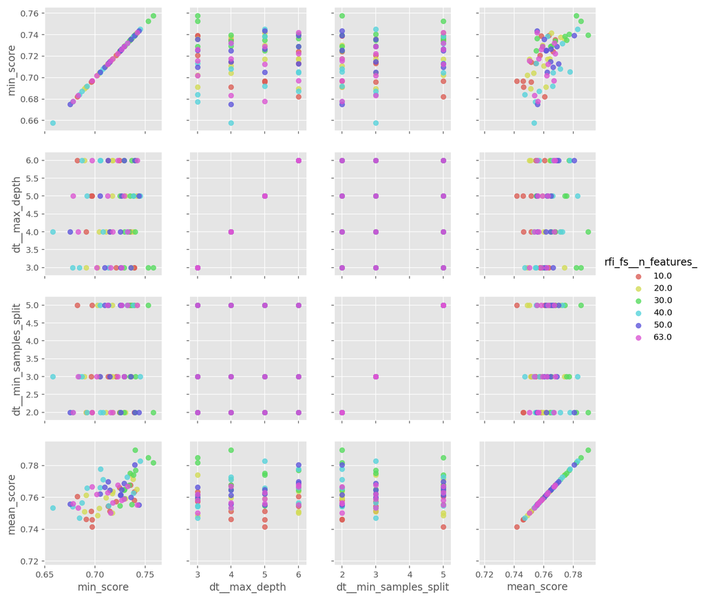

```python
g = sns.PairGrid(results_RF, vars=['min_score', 'dt__max_depth', 'dt__min_samples_split', 'mean_score'],
                 hue='rfi_fs__n_features_', palette='hls')
g.map(plt.scatter, alpha=0.8)
g.add_legend();
```

As obsereved, mean AUC scores for model with different combinations of parameters are not significantly apart from each other.

## 13. Performance Comparison

While conducting hyperparameter tuning, the best parameters for all the best classifiers were found. The next step is to fit the tuned classifier on the test data, in order to understand which classifier performs the best. Further, a 15-fold stratified cross-validation is performed with no repetitions. Area Under Curve is used as performance measurement metric. Random state is fixed to a constant of '999' which makes the data partition exactly same for all classifiers. This makes the results statistically paired.

### 13.1 K-NN

Stratified cross-validation is performed on K-NN model.

```python
from sklearn.model_selection import cross_val_score

cv_ttest = StratifiedKFold(n_splits=15, random_state=999)

cv_KNN = cross_val_score(estimator=g_pipe1.best_estimator_,
                                 X=Dtest,
                                 y=ttest,
                                 cv=cv_ttest,
                                 n_jobs=-3,
                                 scoring='roc_auc')
cv_KNN.mean()
```

```
0.6738095238095239
```

### 13.2 NB

Stratified cross-validation is performed on NB model.

```python
Dtest_trans= PowerTransformer().fit_transform(Dtest)

cv_NB = cross_val_score(estimator=g_pipe4.best_estimator_,
                                X=Dtest_trans,
                                y=ttest,
                                cv=cv_ttest,
                                n_jobs=-3,
                                scoring='roc_auc')
cv_NB.mean()
```

```
0.7055555555555556
```

### 13.3 DT

Stratified cross-validation is performed on DT model.

```python
cv_DT = cross_val_score(estimator=g_pipe2.best_estimator_,
                                X=Dtest,
                                y=ttest,
                                cv=cv_ttest,
                                n_jobs=-3,
                                scoring='roc_auc')
cv_DT.mean()
```

```
0.6603174603174603
```

### 13.4 RF

Stratified cross-validation is performed on RF model.

```python
cv_RF = cross_val_score(estimator=g_pipe5.best_estimator_,
                                X=Dtest,
                                y=ttest,
                                cv=cv_ttest,
                                n_jobs=-3,
                                scoring='roc_auc')
cv_RF.mean()
```

```
0.6777777777777777
```

### 13.5 Paired t-tests

We perform paired t-tests to determine the best classifier. We use 'stats.ttest_rel()' function of scipy package for this. The following t-tests were performed for AUC scores on tuned classifiers:

- K-NN vs NB
- DT vs K-NN
- DT vs NB
- K-NN vs RF
- DT vs RF
- RF vs NB

```python
from scipy import stats

print(stats.ttest_rel(cv_KNN, cv_NB))
print(stats.ttest_rel(cv_DT, cv_KNN))
print(stats.ttest_rel(cv_DT, cv_NB))
print(stats.ttest_rel(cv_KNN, cv_RF))
print(stats.ttest_rel(cv_DT, cv_RF))
print(stats.ttest_rel(cv_RF, cv_NB))
```

```
Ttest_relResult(statistic=-1.5247482713963305, pvalue=0.14959016198826727)
Ttest_relResult(statistic=-0.445882124832062, pvalue=0.6625004287865162)
Ttest_relResult(statistic=-1.5854318542454704, pvalue=0.13519051107461444)
Ttest_relResult(statistic=-0.14648968382726194, pvalue=0.8856233186711558)
Ttest_relResult(statistic=-0.42977041702562413, pvalue=0.673903795343016)
Ttest_relResult(statistic=-1.0458250331675931, pvalue=0.31336358452170315)
```

Null hypothesis in paired t-tests is that average of all the differences between paired observations in both samples is 0. Since the p-values are greater than 0.05, we conclude that no significant difference is found between the classifiers. Hence, we accept the null hypothesis and reject the alternative hypothesis. Hence, all the above classifiers generate a good result for this data.